# Laboratorio 1.1: Exploración y Visualización de Datos

Millaray Valdivia Saldias, Ignacio Díaz Lara

Septiembre 2021

# Declaración de compromiso ético

# Instrucciones

1. Trabajen en equipos de dos personas. Salvo excepciones, no se corregirá entregas con menos de dos integrantes.
2. Modifique este archivo `.Rmd` agregando sus respuestas donde corresponda.
3. Para cada pregunta, cuando corresponda, **incluya el código fuente que utilizó para llegar a su respuesta**.
4. El formato de entrega para esta actividad es un archivo html. **Genere un archivo HTML usando RStudio** y súbalo a U-Cursos.

Basta con que uno de los integrantes haga la entrega. Si ambos hacen una entrega en U-Cursos, se revisará cualquiera de éstas.

# Laboratorio

La primera parte de esta actividad son preguntas teóricas que avanzaron en las clases del curso de Minería de datos.

## Teoría

*1. ¿Cuál es el objetivo de Minería de datos y qué la diferencia de Machine Learning? De un ejemplo para explicar la diferencia.*

**Respuesta: La minería de datos extrae información automáticamente con el fin de generar conocimientos, mientras que el machine learning busca generar predicciones desarrollando algoritmos. La minería de datos puede utilizar el machine learning como herramienta.**

*2. Describa y compare los siguientes métodos usados en Minería de datos: clasificación vs. clustering.*

**Respuesta: Clasificación es asignar la clase más correcta a los datos. El clustering busca los puntos que sean similares entre sí. Comparando la clasificación sería intentar encontrar una clase previamente descrita de los datos, mientras que el clustering busca encontrar patrones para clasificar los datos en grupos.**

*3. ¿Qué es el análisis exploratorio de datos o EDA?*

**Respuesta: Es un conjunto de técnicas que se utilizan para comprender y explorar la naturaleza de un dataset.**

*4. Explique cómo se identifican los valores atípicos u outliers en un boxplot.*

**Respuesta: En un boxplot los outliers se posicionan por encima de los brazos superiores del boxplot o por debajo de los brazos inferiores y representan a un punto muy alejado de la mediana.**

## Práctica

En esta parte de la actividad se trabajará con los datos del Proceso Constituyente 2016-2017 publicados en el Portal de Datos Abiertos del Gobierno de Chile, para mayor información pueden ingresar al siguiente link: https://datos.gob.cl/dataset/proceso-constituyente-abierto-a-la-ciudadania. Los datos corresponden a las actas de los Encuentros Locales Autoconvocados (ELAs), en cada cual, un grupo de personas se reune a discutir distintos conceptos como por ejemplo: salud, educación, seguridad, etc.

Los datos con los que trabajarán consisten en la cantidad de veces que cada concepto constitucional fue mencionado por cada localidad de Chile.

Para cargar los datos, use:

```r
data_tf <- read.csv("http://dcc.uchile.cl/~hsarmien/mineria/datasets/actas.txt", header = T)
```

**Por cada pregunta adjunte el código R que utilizó para llegar a la respuesta. Respuestas sin código no recibirán puntaje**

### Exploración básica

1. ¿Cuáles son las dimensiones del dataset (filas, columnas)? Adjunte código o indique cómo determinó la cantidad de datos total.

```r
dim(data_tf)
```

```
## [1] 328 113
```

2. ¿Qué describe cada línea del dataset? (ejemplifique tomando la fila 45)

```r
data_tf[45,]
```

```
##                       localidad a_huelga a_la_educacion a_la_honra._al_honor
## 45 Biobio/Bio Bio/Santa Barbara        1              2                    0
##    a_la_identidad_cultural a_la_informacion a_la_integracion_de_discapacidad
## 45                       0                0                                1
##    a_la_integridad_fisica_y_psiquica a_la_nacionalidad a_la_participacion
## 45                                 2                 0                  0
##    a_la_salud a_la_seguridad.vida_sin_violencia a_la_seguridad_social a_la_vida
## 45          2                                 1                     1         1
##    a_la_vivienda_digna a_sindicalizarse_y_a_la_negociacion_colectiva
## 45                   1                                             0
##    a_sufragio.votar acceso_a_informacion_publica acceso_a_la_cultura
## 45                2                            0                   0
##    al_salario_equitativo al_trabajo amistad_civica autonomia.libertad
## 45                     1          0              1                  0
##    bien_comun.comunidad cambio_o_reforma_constitucional ciudadania
## 45                    1                               1          0
##    congreso_o_parlamento_.estructura_y_funciones.
## 45                                              1
##    contraloria_general.tribunales_de_cuentas cumplimiento_de_las_leyes_y_normas
## 45                                         1                                  2
##    cumplimiento_de_obligaciones_fiscales
## 45                                     0
##    cumplimiento_de_tratados_y_obligaciones_internacionales
## 45                                                       1
##    de_los_pueblos_indigenas de_peticion_ante_las_autoridades de_propiedad
## 45                        0                                0            0
##    de_proteccion_y_conservacion_de_patrimonio_historico_y_cultural
## 45                                                               3
##    de_satisfacer_cargas_publicas
## 45                             0
##    deberes_de_proteccion_de_conservacion_de_la_naturaleza
## 45                                                      3
##    defensor_del_pueblo.ciudadano democracia derecho_de_asociacion
## 45                             1          3                     0
##    derechos_del_nino._nina_y_adolescente desarrollo descentralizacion dignidad
## 45                                     0          0                 2        1
##    diversidad division_territorial
## 45          1                    0
##    ejercicio_legitimo_y_no_abusivo_de_los_derechos emprendimiento_libre
## 45                                               2                    1
```

[output cut: 33 more lines]

```
## 45                      0        0                                   0
##    proteccion._promocion_y_respeto_de_los_derechos_humanos_y_fundamentales
## 45                                                                       3
##    republica respeto respeto.conservacion_de_la_naturaleza_o_medio_ambiente
## 45         0       1                                                      2
##    respeto_a_la_naturaleza.medio_ambiente respeto_de_derechos_de_otros
## 45                                      1                            2
##    respeto_por_la_constitucion responsabilidad reunion_pacifica
## 45                           1               1                0
##    regimen_de_gobierno_presidencial.semi.presidencial.parlamentario seguridad
## 45                                                                1         0
##    ser_elegido_en_cargos_publicos servicio_a_la_comunidad soberania solidaridad
## 45                              0                       2         0           0
##    subsidiaridad tolerancia transparencia_y_publicidad unidad
## 45             1          1                          0      0
```

3. ¿Existen localidades repetidas en el dataset? Adjunte el código o indique cómo llegó a esa conclusión.

No existen localidades que aparezcan más de una vez.

```r
library(tidyverse)
data_tf %>%
  count(localidad, name="cantidad") %>%  # contamos las localidades en una columna que nombramos cantidad
  filter(cantidad>1)  # filtramos para que sólo aparezcan las que salen más de una vez
```

```
## [1] localidad cantidad
## <0 rows> (or 0-length row.names)
```

### Análisis

1. Liste todas las localidades donde *no* se discutió el concepto `justicia`.

```r
data_tf %>%
  filter(justicia==0) %>% # filtramos donde no se discutió justicia
  select(localidad) # seleccionamos sólo la columna localidad
```

```
##                                                         localidad
## 1   Aisen del General Carlos Ibanez del Campo/Capitan Prat/Tortel
## 2                            Antofagasta/Antofagasta/Sierra Gorda
## 3                                  Antofagasta/Antofagasta/Taltal
## 4                              Arica y Parinacota/Arica/Camarones
## 5                     Arica y Parinacota/Parinacota/General Lagos
## 6                                      Biobio/Bio Bio/Alto Biobio
## 7                                          Biobio/Bio Bio/Mulchen
## 8                                          Biobio/Bio Bio/Negrete
## 9                                          Biobio/Bio Bio/Quilaco
## 10                                     Biobio/Bio Bio/San Rosendo
## 11                                            Biobio/Nuble/Ninhue
## 12                                            Biobio/Nuble/Pemuco
## 13                                           Biobio/Nuble/Ranquil
## 14                                        Biobio/Nuble/San Fabian
## 15                                            Biobio/Nuble/Niquen
## 16                                        Coquimbo/Elqui/Paihuano
## 17                                  La Araucania/Cautin/Melipeuco
## 18                                  La Araucania/Cautin/Perquenco
## 19                                      Los Lagos/Chiloe/Quinchao
## 20                                  Los Lagos/Osorno/Puerto Octay
## 21                                         Los Rios/Ranco/Futrono
## 22 Magallanes y de la Antartica Chilena/Tierra del Fuego/Timaukel
## 23                                          Maule/Talca/Empedrado
## 24                                   Tarapaca/El Tamarugal/Camina
## 25                       Valparaiso/Isla de Pascua/Isla de Pascua
## 26                           Valparaiso/San Antonio/Santo Domingo
## 27                           Valparaiso/Valparaiso/Juan Fernandez
```

2. Liste las 10 localidades que más mencionaron el concepto `al_trabajo`.

```r
al_t <- data_tf %>%
  select(localidad, al_trabajo) %>%  # seleccinamos localidad y al_trabajo
  arrange(-al_trabajo)  # ordenamos decrecientemente
al_t[1:10,]  # visualizamos las primeras diez filas
```

```
##                                           localidad al_trabajo
## 1       Metropolitana de Santiago/Santiago/Santiago         72
## 2          Metropolitana de Santiago/Santiago/Nunoa         44
## 3                  Valparaiso/Valparaiso/Valparaiso         40
## 4    Metropolitana de Santiago/Santiago/Providencia         38
## 5     Metropolitana de Santiago/Santiago/La Florida         28
## 6     Metropolitana de Santiago/Santiago/Las Condes         27
## 7                              Biobio/Nuble/Chillan         21
## 8  Metropolitana de Santiago/Cordillera/Puente Alto         20
## 9       Metropolitana de Santiago/Santiago/Recoleta         20
## 10                     Biobio/Concepcion/Concepcion         19
```

3. Liste los 10 conceptos más mencionados a lo largo de todo el proceso.

```r
library("reshape")
conceptos <- melt(data_tf, id=c("localidad")) # reformateamos la tabla para dejar los conceptos en una columna
conceptos_filtrados <- conceptos %>%
  group_by(variable) %>%  # agrupamos por los conceptos
  summarise(total = sum(value)) %>%  # sumamos la cantidad de apariciones de los conceptos
  arrange(-total)  # ordenamos decrecientemente
conceptos_filtrados[1:10,]  # visualizamos los 10 primeros
```

```
## # A tibble: 10 x 2
##    variable                                                                total
##    <fct>                                                                   <int>
##  1 proteccion._promocion_y_respeto_de_los_derechos_humanos_y_fundamentales  6233
##  2 deberes_de_proteccion_de_conservacion_de_la_naturaleza                   5981
##  3 a_la_salud                                                               5722
##  4 a_la_educacion                                                           5462
##  5 plebiscitos._referendos_y_consultas                                      5305
##  6 igualdad                                                                 5237
##  7 respeto_por_la_constitucion                                              4842
##  8 de_proteccion_y_conservacion_de_patrimonio_historico_y_cultural          4815
##  9 respeto_de_derechos_de_otros                                             4600
## 10 justicia                                                                 4188
```

4. Liste las 10 localidades que más participaron en el proceso. Describa cómo definió su medida de participación.

```r
conceptos <- melt(data_tf, id=c("localidad"))  # reformateamos la tabla para dejar los conceptos en una columna

conceptos_filtrados <- conceptos %>%
  group_by(localidad) %>%  #agrupamos por localidad
  summarise(total = sum(value)) %>%  #sumamos la cantidad de apariciones de los conceptos en la localidad
  arrange(-total)  # ordenamos decrecientemente
conceptos_filtrados[1:10,]  #visualizamos los 10 primeros datos
```

```
## # A tibble: 10 x 2
##    localidad                                        total
##    <chr>                                            <int>
##  1 Metropolitana de Santiago/Santiago/Santiago      12448
##  2 Metropolitana de Santiago/Santiago/Providencia   10234
##  3 Metropolitana de Santiago/Santiago/Nunoa          7675
##  4 Metropolitana de Santiago/Santiago/Las Condes     6608
##  5 Valparaiso/Valparaiso/Valparaiso                  5252
##  6 Metropolitana de Santiago/Cordillera/Puente Alto  4956
##  7 Metropolitana de Santiago/Santiago/La Florida     4036
##  8 Metropolitana de Santiago/Santiago/La Reina       4023
##  9 Valparaiso/Valparaiso/Vina del Mar                3374
## 10 La Araucania/Cautin/Temuco                        3052
```

5. Ejecute el siguiente código que permitirá agregar una nueva columna a nuestro dataframe que solo tendrá el nombre de la región.

```r
library(dplyr)
regiones <- strsplit(as.character(data_tf[,1]), '/')
data_tf$region <- sapply(regiones, "[[", 1)
data_tf <- data_tf %>% select(localidad, region, everything())
```

Luego, genere un gráfico de barras (ggplot) que muestre los 10 conceptos más mencionados en cada una de las regiones mencionadas (adjunte gráficos y código):

- `Coquimbo`
- `Antofagasta`
- `Metropolitana de Santiago`

Cabe resaltar, que se esperan tres gráficos de barras para las tres diferentes regiones:

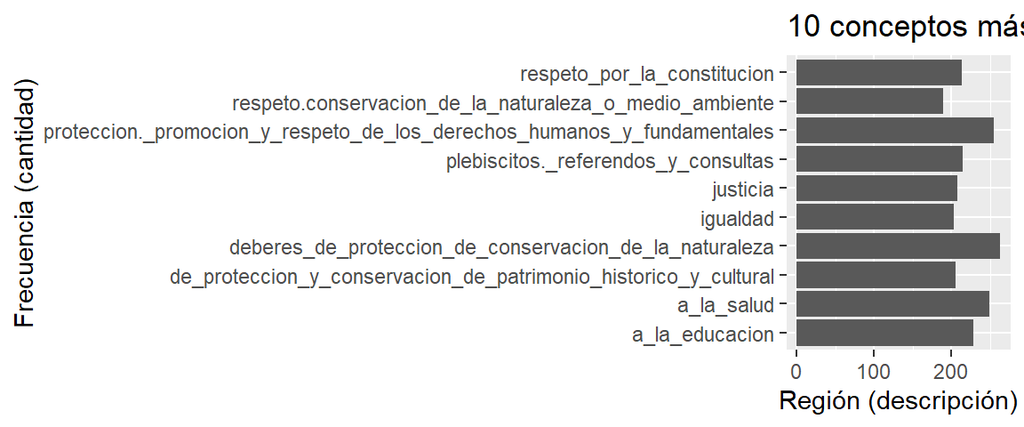

```r
# 10 conceptos más mencionados en Coquimbo
conceptos_coquimbo <- melt(data_tf, id=c("localidad", "region"))  # reformateamos la tabla para dejar los conceptos en una columna

conceptos_filtrados_coquimbo <- conceptos_coquimbo %>%
  filter(region=="Coquimbo")  %>%  # filtramos dejando sólo la región de coquimbo
  group_by(variable) %>%  #agrupamos por los conceptos
  summarise(total = sum(value)) %>%  # sumamos la cantidad de apariciones de los conceptos
  arrange(-total)  # ordenamos decrecientemente

conceptos_filtrados_coquimbo <- conceptos_filtrados_coquimbo[1:10,]  #dejamos sólo los primeros 10 valores

library(ggplot2)
# gráfico de visualización
ggplot(conceptos_filtrados_coquimbo) +
  geom_bar(aes(x = total, y = variable), stat="identity") +
  #coord_flip() +
  ggtitle("10 conceptos más mencionados en Coquimbo") +
  xlab("Región (descripción)") + ylab("Frecuencia (cantidad)")
```

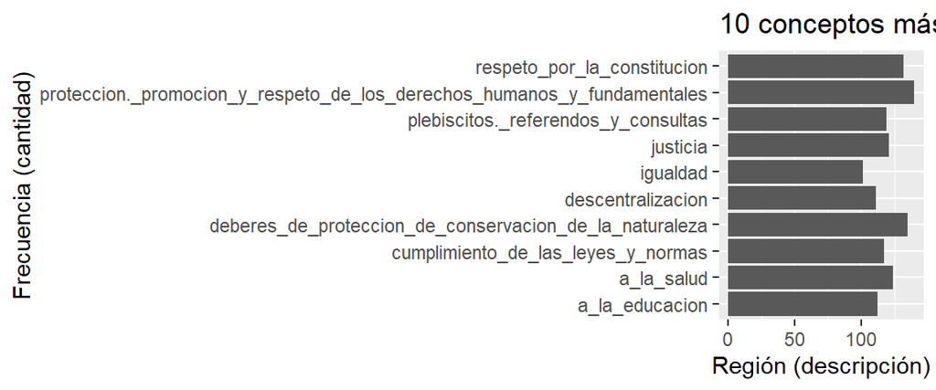

```r
# 10 conceptos más mencionados en Antofagasta
conceptos_antofagasta <- melt(data_tf, id=c("localidad", "region"))  # reformateamos la tabla para dejar los conceptos en una columna

conceptos_filtrados_antofagasta <- conceptos_antofagasta %>%
  filter(region=="Antofagasta")  %>%  # filtramos dejando sólo la región de antofagasta
  group_by(variable) %>%  #agrupamos por los conceptos
  summarise(total = sum(value)) %>%  # sumamos la cantidad de apariciones de los conceptos
  arrange(-total)  # ordenamos decrecientemente

conceptos_filtrados_antofagasta <- conceptos_filtrados_antofagasta[1:10,]  #dejamos sólo los primeros 10 valores


# gráfico de visualización
ggplot(conceptos_filtrados_antofagasta) +
  geom_bar(aes(x = total, y = variable), stat="identity") +
  #coord_flip() +
  ggtitle("10 conceptos más mencionados en Antofagasta") +
  xlab("Región (descripción)") + ylab("Frecuencia (cantidad)")
```

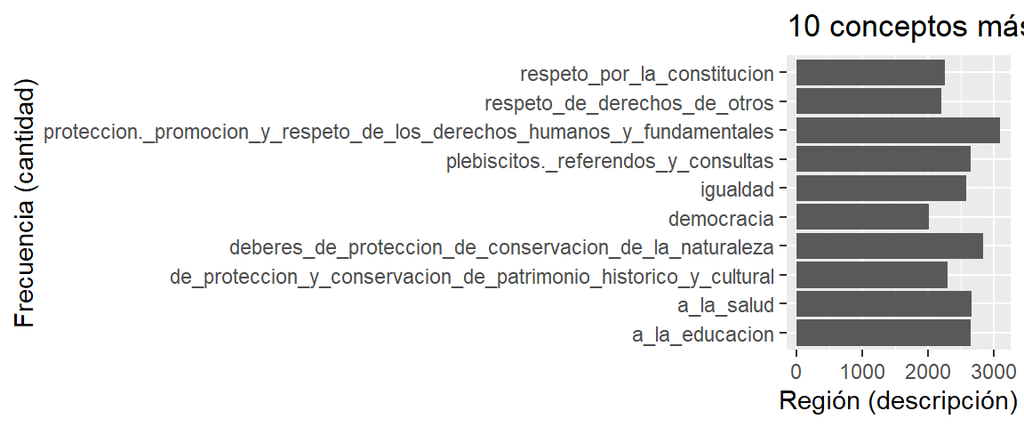

```r
# 10 conceptos más mencionados en Metropolitana de Santiago
conceptos_santiago <- melt(data_tf, id=c("localidad", "region"))  # reformateamos la tabla para dejar los conceptos en una columna

conceptos_filtrados_santiago <- conceptos_santiago %>%
  filter(region=="Metropolitana de Santiago")  %>% # filtramos dejando sólo la región metropolitana de santiago
  group_by(variable) %>%  #agrupamos por los conceptos
  summarise(total = sum(value)) %>%  # sumamos la cantidad de apariciones de los conceptos
  arrange(-total)  # ordenamos decrecientemente

conceptos_filtrados_santiago <- conceptos_filtrados_santiago[1:10,]  #dejamos sólo los primeros 10 valores


# gráfico de visualización
ggplot(conceptos_filtrados_santiago) +
  geom_bar(aes(x = total, y = variable), stat="identity") +
  ggtitle("10 conceptos más mencionados en Metropolitana de Santiago") +
  xlab("Región (descripción)") + ylab("Frecuencia (cantidad)")
```

6. De la pregunta anterior, ¿considera que es razonable usar el conteo de frecuencias para determinar las regiones que tuvieron mayor participación en el proceso? ¿Por qué? Sugiera y solamente comente una forma distinta de hacerlo.

**Respuesta: No creemos que sea la mejor forma de medir participación, si no de interés de temáticas por localidad. Otra forma que creemos que es mejor es contabilizar a la cantidad de personas que asistieron y analizar qué porcentaje de gente vive en la región, para tener una proporción de participación de personas por región.**